# Resposta Em Frequência

## Resposta à Excitação Senoidal

A reposta de um sistema $S$ à uma exponencial de duração infinita com frequência complexa $s$, $e^{st}$, é obtida através da integral de convolução

$$y(t)=e^{st}*h(t)=\int_{-\infty}^{\infty} e^{s\tau}h(t-\tau)\,d\tau=\int_{-\infty}^{\infty}h(\tau)e^{s(t-\tau)}\,d\tau=e^{st}\int_{-\infty}^{\infty}h(\tau)e^{-s\tau}\,d\tau=e^{st}H(s)$$

onde $h(t)$ é a resposta ao impulso.

Podemos escrever simplesmente que

$$e^{st}\Rightarrow H(s)e^{st}$$

Agora, fazendo $s=j\omega$, teremos $H(s)=H(j\omega)$, e portanto

$$e^{j\omega t}\Rightarrow H(j\omega)e^{j\omega t}$$

onde $e^{j\omega t}=\cos{\omega t}+j\sin{\omega t}$. Por isso, tomando apenas a parte real,

$$\Re (e^{j\omega t})=\cos(\omega t) \Rightarrow \Re (H(j\omega)e^{j\omega t})$$

$H(j\omega )=\big|H(j\omega )\big|e^{j\angle H(j\omega)}$. Substituindo na expressão acima, temos

$$\Re (e^{j\omega t})=\cos(\omega t) \Rightarrow \big|H(j\omega )\big|\Re(e^{j(\omega t+\angle H(j\omega))})=\big|H(j\omega )\big|\cos(\omega t+\angle H(j\omega))$$

onde $\big|H(j\omega)\big|$ é o ganho de amplitude, $\angle H(j\omega)$ é a resposta de fase e $H(j\omega)$ é a resposta em frequência do sistema.

**Exemplo** Seja um sistema com função de transferência $H(s)=\frac{s+0.1}{s+5}$, e uma entrada $x(t)=\cos(\omega t)$.

```python
from lcapy import *
H=transfer((s+0.1)/(s+5))
H
```

$$\frac{s + \frac{1}{10}}{s + 5}$$

```python
Hr=H(jomega).val
Hr
```

$$\frac{\mathrm{j} \omega + 0.1}{\mathrm{j} \omega + 5.0}$$

```python
Num=abs(Hr.numerator).val
Den=abs(Hr.denominator).val
Hm=Num/Den
Hm
```

$$\frac{\left(\omega^{2} + \frac{1}{100}\right)^{0.5}}{5 \left(\frac{\omega^{2}}{25} + 1.0\right)^{0.5}}$$

```python
Hf=Hr.phase_degrees.val
Hf
```

$$57.2957795130823 \operatorname{atan}{\left(\frac{49.0 \omega}{10.0 \omega^{2} + 5.0} \right)}$$

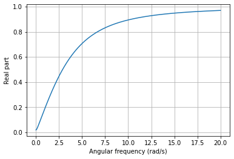

```python
Hm.plot((0,20));
```

```python
Hm(2).val
```

$$0.371854624912701$$

```python
Hm(10).val
```

$$0.894471911241488$$

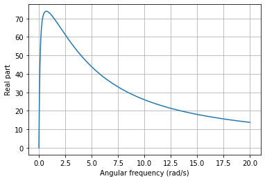

```python
Hf.plot((0,20));
```

```python
Hf(2).val
```

$$65.3361852875364$$

```python
Hf(10).val
```

$$25.9921124793945$$

**Exemplo** O atrasador ideal

Um atrasador ideal de $T$ segundos é um sistema tal que $y(t)=x(t-T)$. Segundo a propriedade do deslocamento no tempo, $Y(s)=e^{-sT}X(s)$. Portanto, a função de transferência do atrasador ideal de $T$ segundos é $H(s)=e^{-sT}$.

```python
T=symbol('T')
H=transfer(exp(-s*T))
Hr=H(jomega)
Hr
```

$$e^{- \mathrm{j} T \omega}$$

```python
Hm=abs(Hr)
Hm
```

$$1$$

```python
Hf=Hr.angle
Hf
```

$$\mathrm{atan_{2}}{\left(- \sin{\left(T \omega \right)},\cos{\left(T \omega \right)} \right)}$$

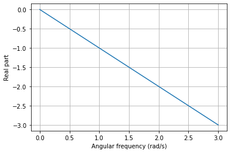

```python
Hf.subs('T',1).plot((0,3));
```

**Exemplo** O diferenciador ideal

Um diferenciador ideal é um sistema tal que $y(t)=\frac{dx(t)}{dt}$. Segundo a propriedade da derivada temporal, $Y(s)=sX(s)$, e a função de transferência é $H(s)=s$.

```python
H=transfer(s)
Hr=H(jomega)
Hr
```

$$\mathrm{j} \omega$$

```python
Hm=abs(Hr)
Hm
```

$$\left|{\omega}\right|$$

```python
Hf=Hr.phase
Hf(6)
```

$$\frac{\pi}{2}$$

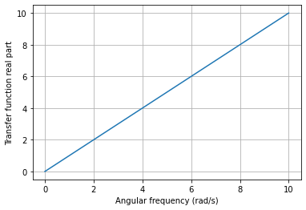

```python
Hm.plot((0,10));
```

**Exemplo** O integrador ideal

Para o integrador ideal, $y(t)=\int_0^t x(\tau)\,d\tau$, e daí, $Y(s)=\frac{X(s)}{s}$. A função de transferência é $H(s)=\frac{1}{s}$.

```python
H=transfer(1/s)
Hr=H(jomega)
Hr
```

$$- \frac{\mathrm{j}}{\omega}$$

```python
Hm=abs(Hr)
Hm
```

$$\frac{1}{\omega}$$

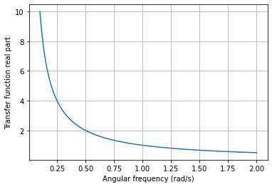

```python
Hm.plot((0.1,2));
```

```python
Hf=Hr.phase
Hf
```

$$- \frac{\pi}{2}$$

### A Resposta em Frequência Para Uma Entrada Senoidal Causal é a Resposta em Regime Permanente

Seja um sistema com função de transferência $H(s)=\frac{P(s)}{Q(s)}$ e entrada $x(t)=e^{j\omega t}u(t)$. A resposta no domínio de Laplace é

$$Y(s)=\frac{P(s)}{Q(s)}X(s)=\frac{P(s)}{Q(s)}\frac{1}{s-j\omega}$$

Expandindo a resposta acima em frações parciais, teremos algo como

$$Y(s)=\frac{A_1}{s+s_1}+ \frac{A_2}{s+s_2}+ \cdots +\frac{A_N}{s+s_N}+\frac{A_{\omega}}{s-j\omega}$$

A transformada inversa de cada um dos primeiros $N$ termos é $A_ie^{-s_it}$, que amortecem assintoticamente para zero quando $t\rightarrow \infty$. Portanto, em regime permanente temos

$$Y(s)=\frac{A_{\omega}}{s-j\omega}$$

e finalmente,

$$A_{\omega}=(s-j\omega)H(s)\frac{1}{(s-j\omega)}\bigg|_{s=j\omega}=H(j\omega)$$

e

$$y(t)=H(j\omega)e^{j\omega t}$$